# Erste Schritte mit `quanteda`: Tokens and Document-Feature-Matrix

### 3.1 Weitere Anwendungen mit DFMs

Mit `dfm_sort` können wir DFMs nach Dokument- und Feature-Frequenzen sortieren:

```r
head(dfm_sort(entscheidungs_dfm, decreasing = TRUE, margin = "both"), n = 12, nf = 10)
```

```
## Document-feature matrix of: 12 documents, 8,318 features (64.78% sparse) and 6 docvars.
##                          features
## docs                        1   2 abs vgl   3   4   s   f   5 bverfgg
##   20170117_2bvb000113.txt 515 488 363 321 198 117 273  87 102      29
##   20190730_2bvr168514.txt 730 445 826 288 286 201 240 162 141      15
##   20180919_2bvf000115.txt 645 531 502 345 309 122 336 169 103       4
##   20160420_1bvr096609.txt 652 406 561 237 188 135  29 131 117       6
##   20161206_1bvr282111.txt 420 167 216 136 189  53  65 113  21       2
##   20171107_2bve000211.txt 255 154 107 164 103  73  45  86  55      12
## [ reached max_ndoc ... 6 more documents, reached max_nfeat ... 8,308 more features ]
```

Mit `dfm_select` lassen sich Wörter gezielt auswählen:

```r
dfm_select(entscheidungs_dfm, pattern = "euro*") # * gibt an, dass wir alle Wörter mit euro als Anfangssequenz suchen
```

```
## Document-feature matrix of: 1,616 documents, 10 features (94.04% sparse) and 6 docvars.
##                          features
## docs                      europa euro europäischen europäische
##   20150108_2bvr241913.txt      1    0            0           0
##   20150112_2bvq005314.txt      0    0            0           0
##   20150113_1bvr047214.txt      0    0            0           0
##   20150113_1bvr332314.txt      0    1            0           0
##   20150113_2bve000113.txt      2    0            3           0
##   20150113_2bvr239514.txt      0    0            0           0
##                          features
## docs                      europarechtlichen europäisches europäischer european
##   20150108_2bvr241913.txt                 0            0            0        0
##   20150112_2bvq005314.txt                 0            0            0        0
##   20150113_1bvr047214.txt                 0            0            0        0
##   20150113_1bvr332314.txt                 0            0            0        0
##   20150113_2bve000113.txt                 0            0            0        0
##   20150113_2bvr239514.txt                 0            0            0        0
##                          features
## docs                      eurosystem eurosystems
##   20150108_2bvr241913.txt          0           0
##   20150112_2bvq005314.txt          0           0
##   20150113_1bvr047214.txt          0           0
##   20150113_1bvr332314.txt          0           0
##   20150113_2bve000113.txt          0           0
##   20150113_2bvr239514.txt          0           0
## [ reached max_ndoc ... 1,610 more documents ]
```

```r
dfm_select(entscheidungs_dfm, pattern = "bund*")
```

```
## Document-feature matrix of: 1,616 documents, 59 features (95.37% sparse) and 6 docvars.
##                          features
## docs                      bundesverfassungsgerichts bundesgerichtshof
##   20150108_2bvr241913.txt                         2                 1
##   20150112_2bvq005314.txt                         1                 0
##   20150113_1bvr047214.txt                         1                 0
##   20150113_1bvr332314.txt                         1                 0
##   20150113_2bve000113.txt                         3                 0
##   20150113_2bvr239514.txt                         2                 0
##                          features
## docs                      bundestages bund bundes bundestag bundesvorsitzenden
##   20150108_2bvr241913.txt           0    0      0         0                  0
##   20150112_2bvq005314.txt           0    0      0         0                  0
##   20150113_1bvr047214.txt           0    0      0         0                  0
##   20150113_1bvr332314.txt           0    0      0         0                  0
##   20150113_2bve000113.txt           2    1      1         3                  5
##   20150113_2bvr239514.txt           0    0      0         0                  0
##                          features
## docs                      bundesrat bundesregierung bundeskanzlerin
##   20150108_2bvr241913.txt         0               0               0
##   20150112_2bvq005314.txt         0               0               0
##   20150113_1bvr047214.txt         0               0               0
##   20150113_1bvr332314.txt         0               0               0
##   20150113_2bve000113.txt         1               1               1
##   20150113_2bvr239514.txt         0               0               0
## [ reached max_ndoc ... 1,610 more documents, reached max_nfeat ... 49 more features ]
```

Die Funktion `dfm_wordstem` reduziert alle Wörter auf ihre Wortstämme:

```r
dfm_wordstem(entscheidungs_dfm, language = "german")
```

```
## Document-feature matrix of: 1,616 documents, 5,644 features (92.59% sparse) and 6 docvars.
##                          features
## docs                       2 13 verfahr s bevollmachtigt rechtsanwalt 75 kiel a
##   20150108_2bvr241913.txt 11  8       1 1              1            1  1    8 2
##   20150112_2bvq005314.txt  7  0       1 1              0            0  0    0 0
##   20150113_1bvr047214.txt  1  3       1 1              1            0  0    0 1
##   20150113_1bvr332314.txt  5  1       2 2              0            2  0    0 0
##   20150113_2bve000113.txt 12  5       3 0              1            0  0    0 0
##   20150113_2bvr239514.txt 19  2       4 1              0            0  0    0 0
##                          features
## docs                      landgericht
##   20150108_2bvr241913.txt           3
##   20150112_2bvq005314.txt           0
##   20150113_1bvr047214.txt           0
##   20150113_1bvr332314.txt           0
##   20150113_2bve000113.txt           0
##   20150113_2bvr239514.txt           3
## [ reached max_ndoc ... 1,610 more documents, reached max_nfeat ... 5,634 more features ]
```

Das Stemming ist im Allgemeinen eine tolle Möglichkeit zur weiteren Informationsreduktion. Für die deutsche Sprache ist es jedoch weniger wirkungsvoll, hier bieten sich andere Verfahren wie zum Beispiel **lemmatization** an.

Wir können DFMs auch nach relativen Worthäufigkeiten gewichten. Die TF-IDF (term frequency - inverse document frequency) zum Beispiel ist ein statistisches Maß, das bewertet, wie relevant ein Wort für ein Dokument in einer Sammlung von Dokumenten ist. Das geschieht durch die Multiplikation zweier Metriken: 1) wie oft ein Wort in einem Dokument vorkommt und 2) die inverse Dokumenthäufigkeit des Wortes über alle Dokumente hinweg.

```r
entscheidungs_dfm_weighted <- dfm_tfidf(entscheidungs_dfm)
topfeatures(entscheidungs_dfm_weighted)
```

```
##   antragsgegnerin      europäischen                nr       gesetzgeber
##          2932.732          2203.311          2192.305          2072.679
##               sgb            urteil beschwerdeführers             seien
##          1994.748          1643.206          1607.167          1591.095
##              2011              2017
##          1539.390          1505.244
```

Wie ihr seht, erzeugt die Gewichtung aussagekräftigere Resultate

### 3.2. Visualisierungen

Natürlich lassen sich DFMs auch visualisieren. Am wohl bekanntesten sind word clouds, die ihr ja bereits kennengelernt habt:

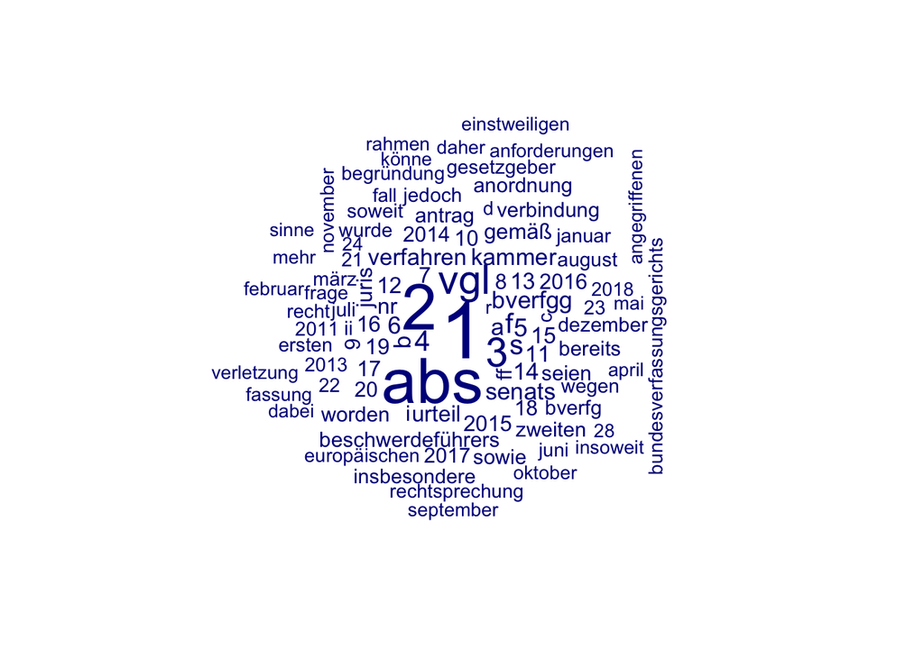

```r
textplot_wordcloud(entscheidungs_dfm, max_words = 100, scale = c(5,1))
```

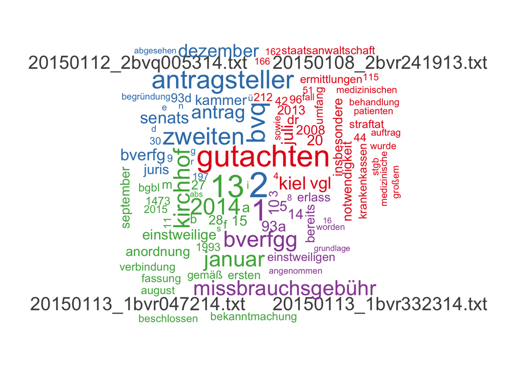

```r
textplot_wordcloud(entscheidungs_dfm[1:4,], color = brewer.pal(4, "Set1"), comparison = T)
```

Nachdem ihr jetzt die Grundlagen der QTA, also Corpus, Tokens und DFM kennengelernt habt, werden wir ab der nächsten Woche mit der eigentlichen Textanalyse.